# Q2

```r
library(sf); library(tmap); library(gstat)
```

```r
# Load the precipitation shapefile (EPSG:4326) and Singapore boundary shapefile (EPSG:3414)
precip <- st_read("precip.shp")
precip
```

```
## Simple feature collection with 464 features and 1 field
## Geometry type: POINT
## Dimension:     XY
## Bounding box:  xmin: 103.6079 ymin: 1.186817 xmax: 104.0831 ymax: 1.464962
## Geodetic CRS:  WGS 84
## First 10 features:
##      precip                  geometry
## 1  2.889559 POINT (103.9743 1.328333)
## 2  0.000000 POINT (103.7269 1.399408)
## 3  3.653491  POINT (103.8571 1.27736)
## 4  2.612957 POINT (103.7393 1.325035)
## 5  0.000000 POINT (103.7913 1.273241)
## 6  3.442024 POINT (104.0667 1.375097)
## 7  2.263137   POINT (103.8695 1.4208)
## 8  3.570655 POINT (103.7235 1.356269)
## 9  3.757454 POINT (103.9893 1.346786)
## 10 3.144331 POINT (103.9023 1.317957)
```

```r
sg <- st_read("sg.shp")
sg
```

```
## Simple feature collection with 1 feature and 1 field
## Geometry type: MULTIPOLYGON
## Dimension:     XY
## Bounding box:  xmin: 2667.538 ymin: 15748.72 xmax: 56396.44 ymax: 50256.33
## Projected CRS: SVY21
##   FID                       geometry
## 1   0 MULTIPOLYGON (((17759.05 15...
```

```r
# Ensure coordinate reference systems are set correctly
st_crs(precip) # Verify CRS is EPSG:4326
```

```
## Coordinate Reference System:
##   User input: WGS 84
##   wkt:
## GEOGCRS["WGS 84",
##     DATUM["World Geodetic System 1984",
##         ELLIPSOID["WGS 84",6378137,298.257223563,
##             LENGTHUNIT["metre",1]]],
##     PRIMEM["Greenwich",0,
##         ANGLEUNIT["degree",0.0174532925199433]],
##     CS[ellipsoidal,2],
##         AXIS["latitude",north,
##             ORDER[1],
##             ANGLEUNIT["degree",0.0174532925199433]],
##         AXIS["longitude",east,
##             ORDER[2],
##             ANGLEUNIT["degree",0.0174532925199433]],
##     ID["EPSG",4326]]
```

```r
st_crs(sg) # Verify CRS is EPSG:3414
```

```
## Coordinate Reference System:
##   User input: SVY21
##   wkt:
## PROJCRS["SVY21",
##     BASEGEOGCRS["GCS_SVY21_WGS84",
##         DATUM["World Geodetic System 1984",
##             ELLIPSOID["WGS 84",6378137,298.257223563,
##                 LENGTHUNIT["metre",1]],
##             ID["EPSG",6326]],
##         PRIMEM["Greenwich",0,
##             ANGLEUNIT["Degree",0.0174532925199433]]],
##     CONVERSION["unnamed",
##         METHOD["Transverse Mercator",
##             ID["EPSG",9807]],
##         PARAMETER["Latitude of natural origin",1.36666666666667,
##             ANGLEUNIT["Degree",0.0174532925199433],
##             ID["EPSG",8801]],
##         PARAMETER["Longitude of natural origin",103.833333333333,
##             ANGLEUNIT["Degree",0.0174532925199433],
##             ID["EPSG",8802]],
##         PARAMETER["Scale factor at natural origin",1,
##             SCALEUNIT["unity",1],
##             ID["EPSG",8805]],
##         PARAMETER["False easting",28001.642,
##             LENGTHUNIT["metre",1],
##             ID["EPSG",8806]],
##         PARAMETER["False northing",38744.572,
##             LENGTHUNIT["metre",1],
##             ID["EPSG",8807]]],
##     CS[Cartesian,2],
##         AXIS["(E)",east,
##             ORDER[1],
##             LENGTHUNIT["metre",1,
##                 ID["EPSG",9001]]],
##         AXIS["(N)",north,
##             ORDER[2],
##             LENGTHUNIT["metre",1,
##                 ID["EPSG",9001]]]]
```

```r
# Transform Singapore boundary CRS to match precipitation CRS
sg_transformed <- st_transform(sg, st_crs(precip))

# Check if geometries are valid after CRS transformation
validity_check <- st_is_valid(sg_transformed)
validity_check
```

```
## [1] TRUE
```

```r
# If any geometries are invalid, print them
if (any(!validity_check)) {
  cat("Invalid geometries found:\n")
  print(sg_transformed[!validity_check, ])
} else {
  cat("All geometries are valid.\n")
}
```

```
## All geometries are valid.
```

```r
# Voronoi tessellation
precip_sp <- as(precip, "Spatial") # Convert to spatial object
voro_sp <- dismo::voronoi(precip_sp) # Generate Voronoi polygons
voro_sf <- st_as_sf(voro_sp) # Convert back to sf object

# Clip Voronoi polygons to Singapore boundary
voro_clipped <- st_intersection(voro_sf, sg_transformed)
```

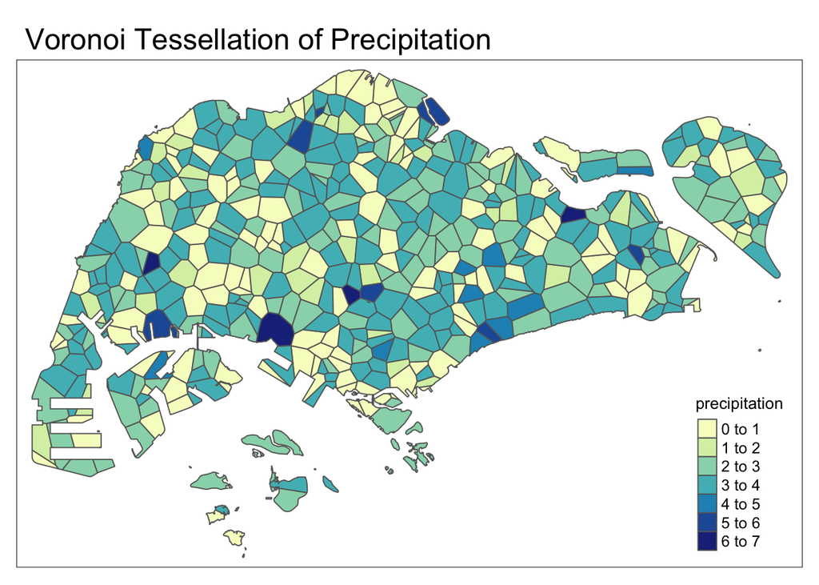

```r
# Generate the plot
voro_plot <- tm_shape(voro_clipped) +
  tm_polygons(col = "precip",
              palette = "YlGnBu",
              title = "precipitation",
              style = "fixed",
              breaks = seq(0, 7, 1)) + # Define legend breaks (0 to 7)
  tm_layout(main.title = "Voronoi Tessellation of Precipitation",
            legend.title.size = 1,
            legend.text.size = 0.8)

# Display the plot
voro_plot
```

```r
# Define the number of grid points (100 x 100 = 10,000)
grid_size <- 100

# Create a bounding box for Singapore's boundary
sg_bbox <- st_bbox(sg_transformed)

# Generate a grid of points within the bounding box
x_seq <- seq(sg_bbox["xmin"], sg_bbox["xmax"], length.out = grid_size)
y_seq <- seq(sg_bbox["ymin"], sg_bbox["ymax"], length.out = grid_size)

# Create a data frame of grid coordinates
grid_points <- expand.grid(x = x_seq, y = y_seq)

# Convert to an sf object with the same CRS as Singapore's boundary
grid_sf <- st_as_sf(grid_points, coords = c("x", "y"), crs = st_crs(sg_transformed))

# Clip the grid to the Singapore boundary
grid_clipped <- st_intersection(grid_sf, sg_transformed)
```

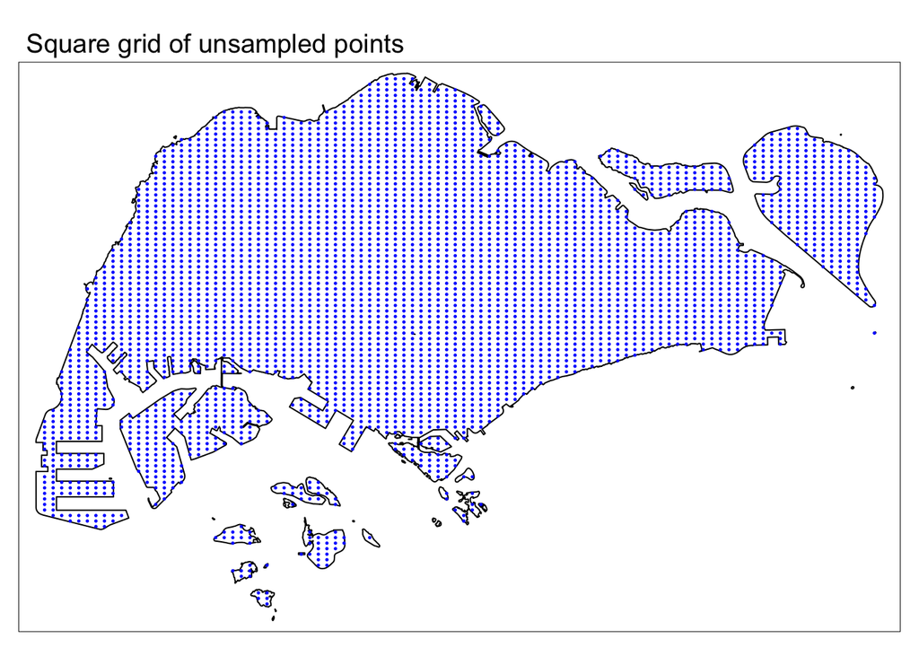

```r
# Plot the grid points
grid_plot <- tm_shape(sg_transformed) +
  tm_borders(col = "black") +
  tm_shape(grid_clipped) +
  tm_dots(size = 0.01, col = "blue") +
  tm_layout(main.title = "Square grid of unsampled points",
            main.title.size = 1.2)

# Display the plot
grid_plot
```

```r
# Convert grid and precipitation data to spatial objects
grid_sp <- as(grid_clipped, "Spatial")
precip_sp <- as(precip, "Spatial")

# Create an empty raster based on the grid for interpolation
raster_template <- raster::raster(extent(grid_sp),
                                  res = c((st_bbox(sg_transformed)$xmax - st_bbox(sg_transformed)$xmin) / 100,
                                  (st_bbox(sg_transformed)$ymax - st_bbox(sg_transformed)$ymin) / 100),
                          crs = st_crs(sg_transformed)$proj4string)

# Perform IDW interpolation with idp=1
idw_1 <- idw(formula = precip ~ 1, locations = precip_sp, newdata = grid_sp, idp = 1)
```

```
## [inverse distance weighted interpolation]
```

```r
raster_idw_1 <- raster::rasterize(grid_sp, raster_template, field = idw_1$var1.pred)

# Perform IDW interpolation with idp=3
idw_3 <- idw(formula = precip ~ 1, locations = precip_sp, newdata = grid_sp, idp = 3)
```

```
## [inverse distance weighted interpolation]
```

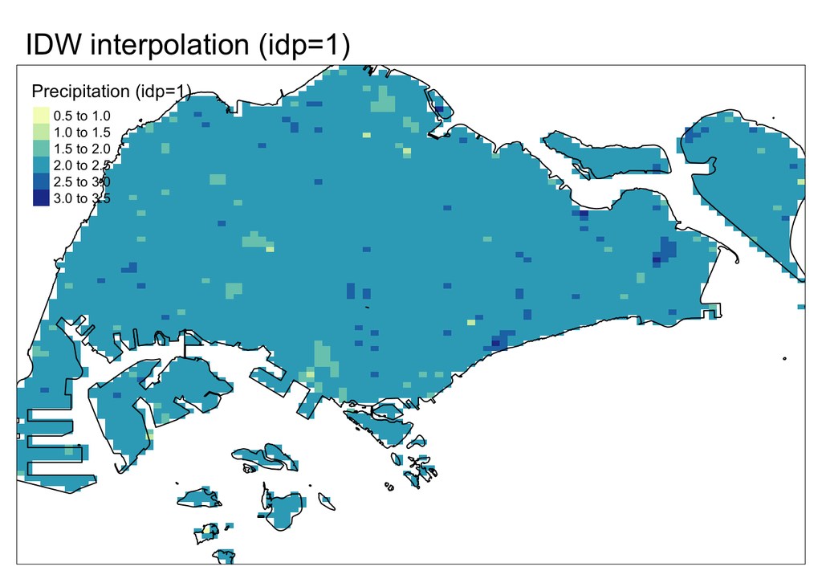

```r
raster_idw_3 <- rasterize(grid_sp, raster_template, field = idw_3$var1.pred)

# Plot the results for idp=1 directly using the raster
idw_1_plot <- tm_shape(raster_idw_1) +
  tm_raster(palette = "YlGnBu", title = "Precipitation (idp=1)") +
  tm_shape(sg_transformed) +
  tm_borders(col = "black") +
  tm_layout(main.title = "IDW interpolation (idp=1)")
idw_1_plot
```

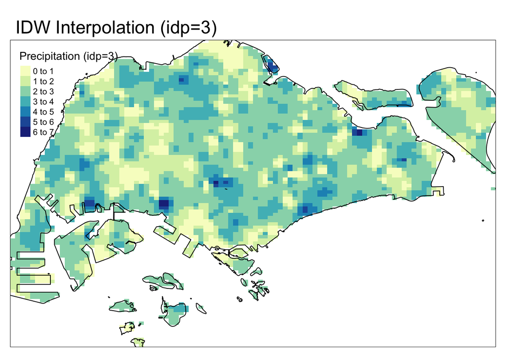

```r
# Plot the results for idp=3 directly using the raster
idw_3_plot <- tm_shape(raster_idw_3) +
  tm_raster(palette = "YlGnBu", title = "Precipitation (idp=3)") +
  tm_shape(sg_transformed) +
  tm_borders(col = "black") +
  tm_layout(main.title = "IDW Interpolation (idp=3)")
idw_3_plot
```

Comment: Based on the two visualisations:

1. IDW with `idp=1`: This interpolation produces a smoother distribution of precipitation values across Singapore. It emphasises regional patterns, creating a gradual transition in precipitation levels and reducing localised variations.
2. IDW with `idp=3`: This version emphasises localised variations, showing more distinct differences in precipitation across small areas. Higher `idp` values place greater weight on nearby points, resulting in a more “patchy” distribution, which highlights small, localised fluctuations in precipitation.

##### Which `idp` is more appropriate?

The choice of `idp` depends on the objective of the interpolation:

- If the goal is to capture broader, regional trends in precipitation, where gradual changes are expected over larger areas, then `idp=1` is more appropriate.
- If the goal is to capture highly localised variations, then `idp=3` would be more suitable as it shows sharper changes and highlights localised precipitation differences.

##### Practicality in the Singapore context

The context of Singapore, a densely populated urban environment with relatively small geographical area, capturing broader precipitation trends rather than localised micro-variations is more practical and useful for urban planning, infrastructure design, and flood management. Therefore, `idp=1` is the preferred choice for interpolating precipitation data in Singapore.

Using `idp=1` provides a smoother, more generalised precipitation map, which aligns well with the need for a cohesive overview of rainfall patterns across the city-state. This approach reduces noise from small-scale variations, offering a clearer picture of regional precipitation trends that can be more effectively applied to large-scale decision-making processes in Singapore’s urban context.

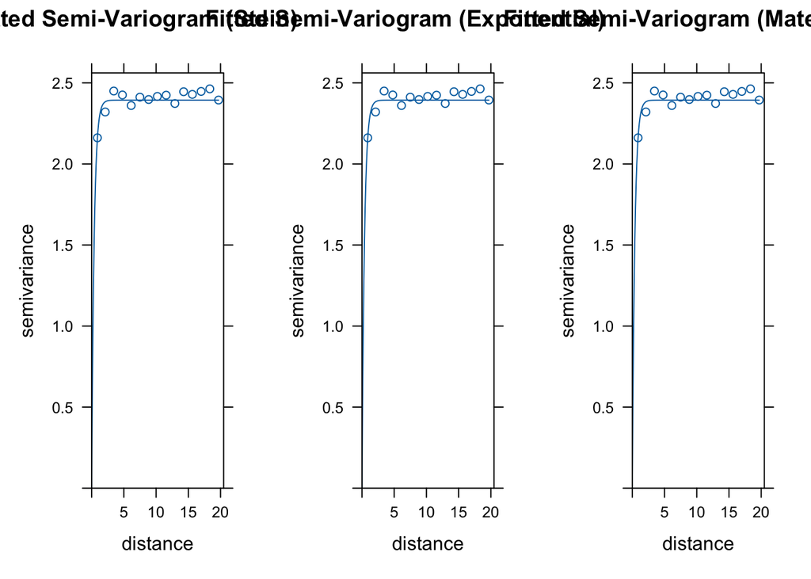

```r
# i.
library(automap)
# Estimate empirical semi-variogram
sv <- variogram(precip ~ 1, precip_sp)

# Fit parametric models for the semi-variogram: Stein, Exponential, and Matern
sv_stein <- fit.variogram(sv, vgm(psill=1, model="Ste", range=0.1), warn.if.neg=TRUE)
sv_exp <- fit.variogram(sv, vgm(psill=1, model="Exp", range=0.1), warn.if.neg=TRUE)
sv_matern <- fit.variogram(sv, vgm(psill=1, model="Mat", range=0.1, kappa=0.5), warn.if.neg=TRUE)

# Plot the empirical and fitted semi-variograms
plot_stein <- plot(sv, model = sv_stein, main = "Fitted Semi-Variogram (Stein)")
plot_exp <- plot(sv, model = sv_exp, main = "Fitted Semi-Variogram (Exponential)")
plot_matern <- plot(sv, model = sv_matern, main = "Fitted Semi-Variogram (Matern)")

# Display all plots to compare and select the best model visually
library(gridExtra)
grid.arrange(plot_stein, plot_exp, plot_matern, nrow = 1)
```

```r
# Select the best model
best_model <- sv_exp
best_model
```

```
##   model   psill     range
## 1   Exp 2.39348 0.3857657
```

```r
# ii.
# Perform simple kriging with the selected model and a known mean (e.g., mean of precipitation data)
mean_precip <- mean(precip_sp$precip, na.rm = TRUE) # Set known mean value
sk_result <- krige(precip ~ 1, locations = precip_sp, newdata = grid_sp, model = best_model, beta = mean_precip)
```

```
## [using simple kriging]
```

```r
summary(sk_result)
```

```
## Object of class SpatialPointsDataFrame
## Coordinates:
##                  min        max
## coords.x1 103.610577 104.083606
## coords.x2   1.168156   1.467623
## Is projected: FALSE
## proj4string : [+proj=longlat +datum=WGS84 +no_defs]
## Number of points: 4145
## Data attributes:
##    var1.pred         var1.var
##  Min.   :0.1384   Min.   :0.08228
##  1st Qu.:2.0881   1st Qu.:2.04569
##  Median :2.2921   Median :2.27934
##  Mean   :2.2567   Mean   :2.13018
##  3rd Qu.:2.4776   3rd Qu.:2.36159
##  Max.   :5.4746   Max.   :2.39348
```

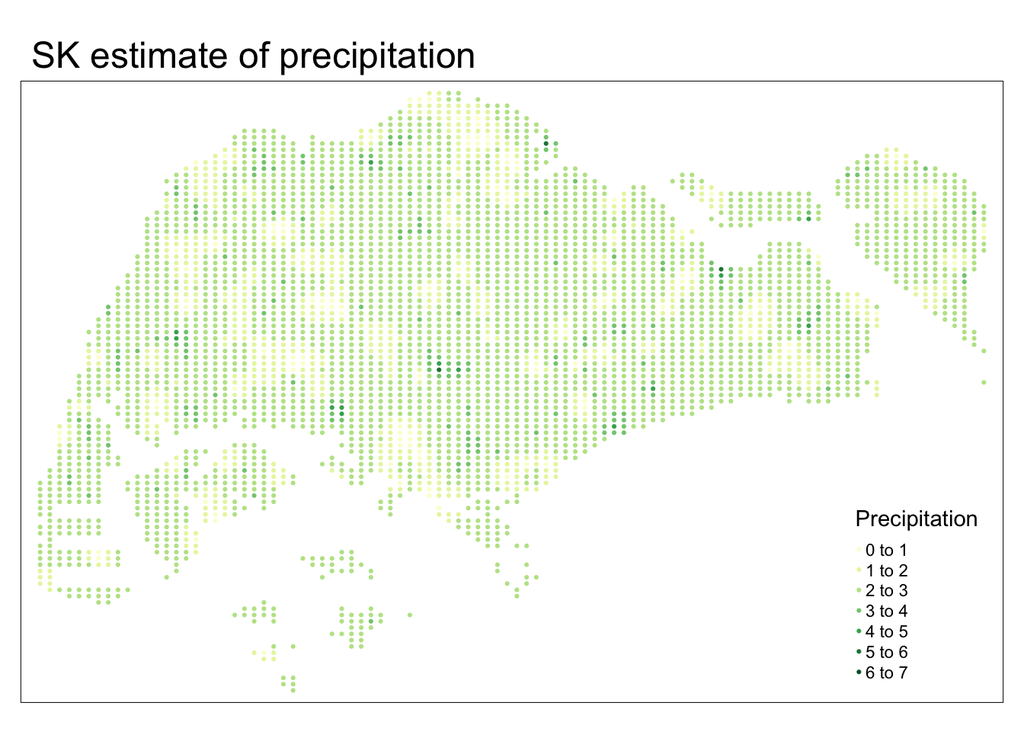

```r
# iii.
# Plot the reconstructed topology with breaks comparable to the Voronoi tessellation in part (a)
sk_plot <- tm_shape(sk_result_sf) +
  tm_dots("var1.pred", palette = "YlGn", breaks = c(0, 1, 2, 3, 4, 5, 6, 7), title = "Precipitation") +
  tm_layout(main.title = "SK estimate of precipitation")

# Display the plot
sk_plot
```

```r
# Perform ordinary kriging with the selected model
ok_result <- krige(precip ~ 1, locations = precip_sp, newdata = grid_sp, model = best_model)
```

```
## [using ordinary kriging]
```

```r
summary(ok_result)
```

```
## Object of class SpatialPointsDataFrame
## Coordinates:
##                  min        max
## coords.x1 103.610577 104.083606
## coords.x2   1.168156   1.467623
## Is projected: FALSE
## proj4string : [+proj=longlat +datum=WGS84 +no_defs]
## Number of points: 4145
## Data attributes:
##    var1.pred         var1.var
##  Min.   :0.1382   Min.   :0.08228
##  1st Qu.:2.0815   1st Qu.:2.04794
##  Median :2.2855   Median :2.28253
##  Mean   :2.2510   Mean   :2.13360
##  3rd Qu.:2.4717   3rd Qu.:2.36652
##  Max.   :5.4724   Max.   :2.40080
```

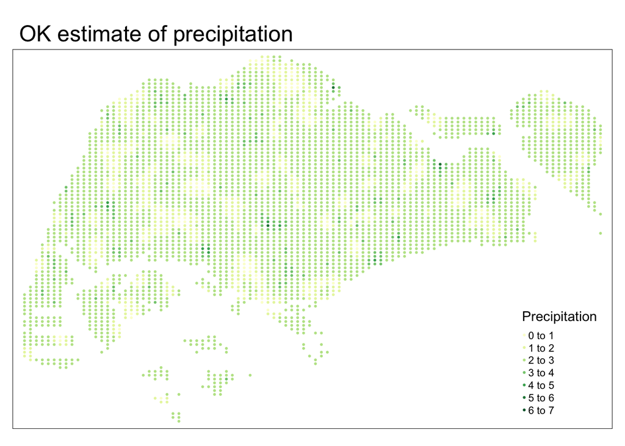

```r
# iii.
# Plot the reconstructed topology with breaks comparable to the Voronoi tessellation in part (a)
ok_plot <- tm_shape(sk_result_sf) +
  tm_dots("var1.pred", palette = "YlGn", breaks = c(0, 1, 2, 3, 4, 5, 6, 7), title = "Precipitation") +
  tm_layout(main.title = "OK estimate of precipitation")

# Display the plot
ok_plot
```

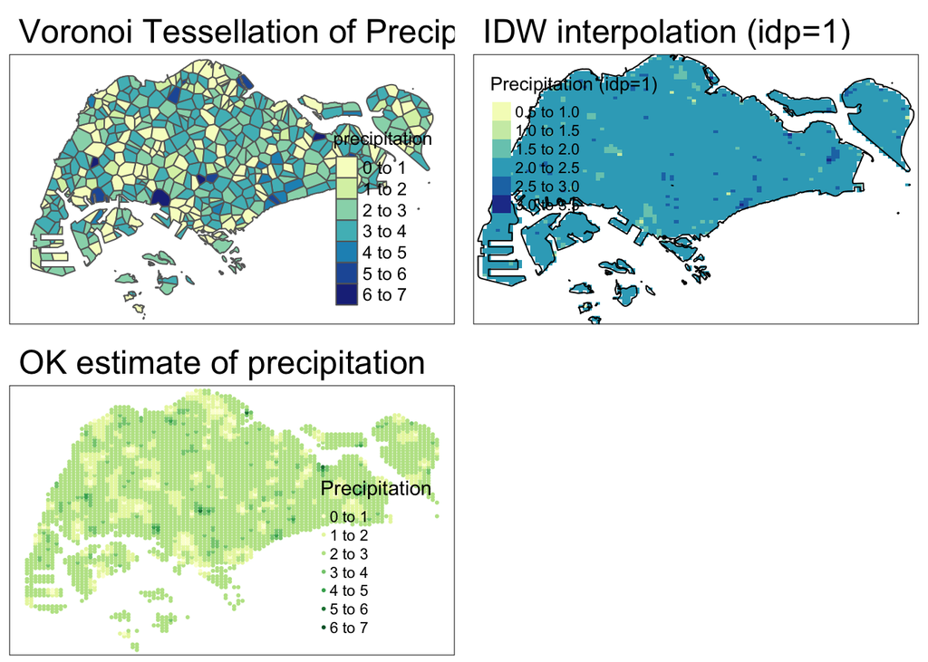

```r
# Arrange the three plots side by side
tmap_arrange(voro_plot, idw_1_plot, ok_plot)
```